# VLM Wrong Predictions: fall_height_bin [both_wrong]

**Model:** VLM vs DINOv3  
**Attribute:** fall_height_bin [both_wrong]  
**Wrong assets:** 9 of 9 (100.0% asset-level error rate)

Asset 122831 2 images

Predicted: VLM: low (<0.5m) | DINOv3: low (<1.2m) (conf: N/A)

Actual: medium (0.5-1.2m)

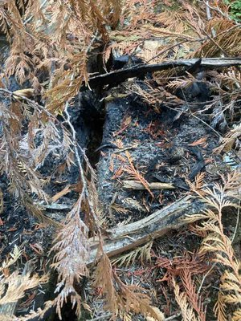

75885__AST_IM_20241024_104750.jpeg

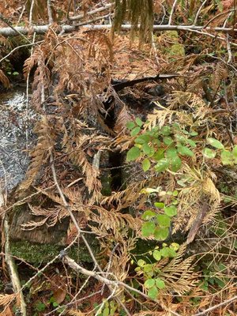

75891__AST_IM_20241024_104743.jpeg

Asset 129378 1 image

Predicted: VLM: unable to determine | DINOv3: low (<1.2m) (conf: N/A)

Actual: medium (0.5-1.2m)

[figure not shown]

92385__AST_EX_20260120_112436.jpeg

Asset 51537 4 images

Predicted: VLM: high (>1.2m) | DINOv3: medium (1.2-5m) (conf: N/A)

Actual: medium (0.5-1.2m)

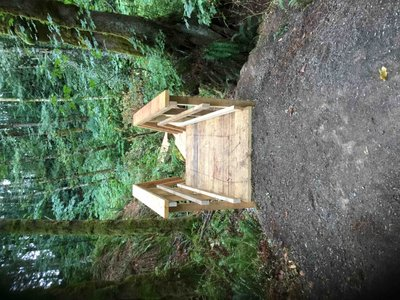

77900__AST_EX_20210826_112045_1_.jpeg

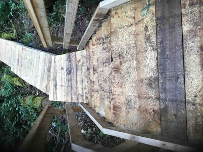

77901__AST_EX_20210826_112118_1_.jpeg

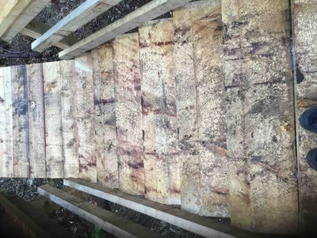

77902__AST_EX_20210826_112202_1_.jpeg

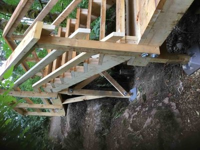

77903__AST_EX_20210826_113218_1_.jpeg

Asset 126700 1 image

Predicted: VLM: low (<0.5m) | DINOv3: medium (0.5-1.2m) (conf: N/A)

Actual: high (>1.2m)

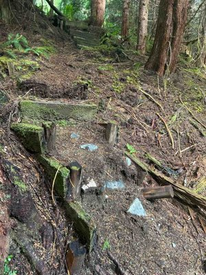

85338__AST_IM_20250723_132622.jpeg

Asset 126777 1 image

Predicted: VLM: high (>1.2m) | DINOv3: high (>1.2m) (conf: N/A)

Actual: medium (0.5-1.2m)

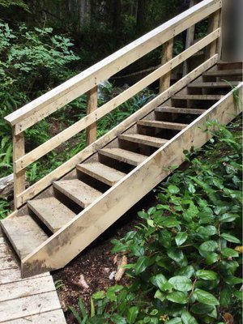

85614__AST_IM_20250730_123236.jpeg

Asset 59060 4 images

Predicted: VLM: low (<1.2m) | DINOv3: low (<1.2m) (conf: N/A)

Actual: medium (1.2-5m)

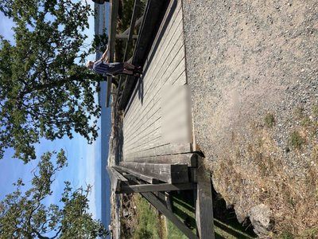

12286__AST_EX_20210810_125200.jpeg

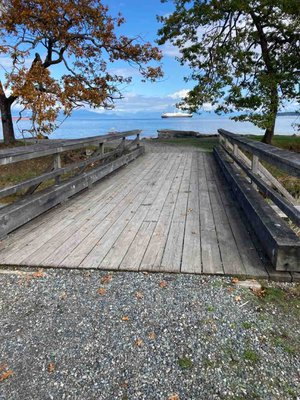

24555__AST_EX_20210928_140314.jpeg

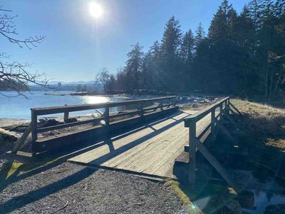

87425__AST_EX_20250128_141116.jpeg

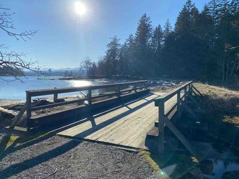

87431__AST_EX_20250128_141116.jpeg

Asset 126178 1 image

Predicted: VLM: low (<1.2m) | DINOv3: medium (0.5-1.2m) (conf: N/A)

Actual: medium (1.2-5m)

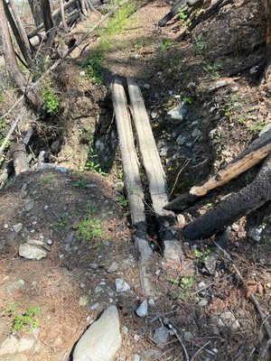

83472__AST_IM_20250611_112515.jpeg

Asset 126683 1 image

Predicted: VLM: low (<1.2m) | DINOv3: low (<1.2m) (conf: N/A)

Actual: medium (1.2-5m)

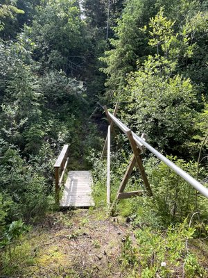

85305__IMG_2174.jpg

Asset 126779 2 images

Predicted: VLM: low (<1.2m) | DINOv3: low (<1.2m) (conf: N/A)

Actual: medium (1.2-5m)

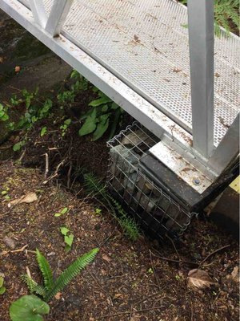

85619__AST_IM_20250730_115639.jpeg

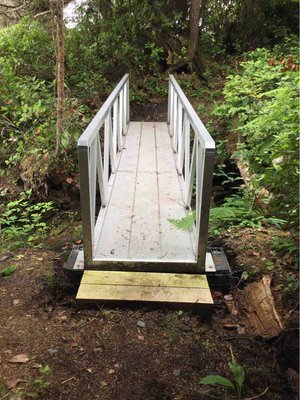

85621__AST_IM_20250730_115624.jpeg